# Montag children’s book corpus

gender analysis - using gender bias from word embedding models

Molly Lewis

2018-03-12

### Gender score from word embedding models

To calculate gender bias measures from word embedding models, I used the [fasttext models trained on wikipedia](https://github.com/facebookresearch/fastText/blob/master/pretrained-vectors.md).

For each word in the Montag corpus, I took the mean distance to 6 “male” words (“boy”, “man”, “male”, “he”, “him”, “his”) and the mean distance to 6 “female” words (“girl”, “woman”, “female”, “she”, “her”, “hers”), and subtracted the two. Positive numbers indicate male bias. There are 333 words missing from the wikipedia models that are in the book corpus (6%). These are contractions (e.g. “George’s”) and non-words (e.g. “whooooooo”).

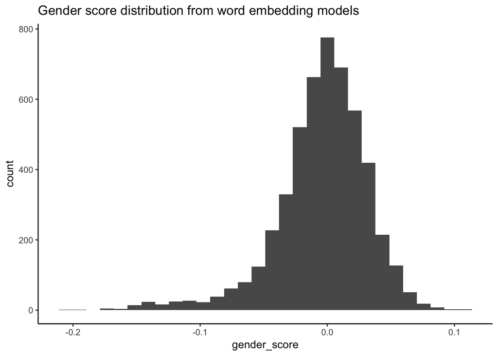

```r
w2v_norms <- read_csv("gender_score_output.csv",
                      col_names = c("target_word", "female_score",
                                    "male_score", "gender_score")) %>%
  distinct(.keep_all = T) %>%
  anti_join(stop_words %>% filter(lexicon == "SMART"),
            by = c("target_word" = "word"))

ggplot(w2v_norms, aes(x = gender_score)) +
    ggtitle("Gender score distribution from word embedding models")+
    geom_histogram() +
    theme_classic()
```

Overall, the words are roughly normally distributed around 0, indicating that - on average - the word types are not biased.

#### Comparing gender score to explicit human norms (Glasglow norms)

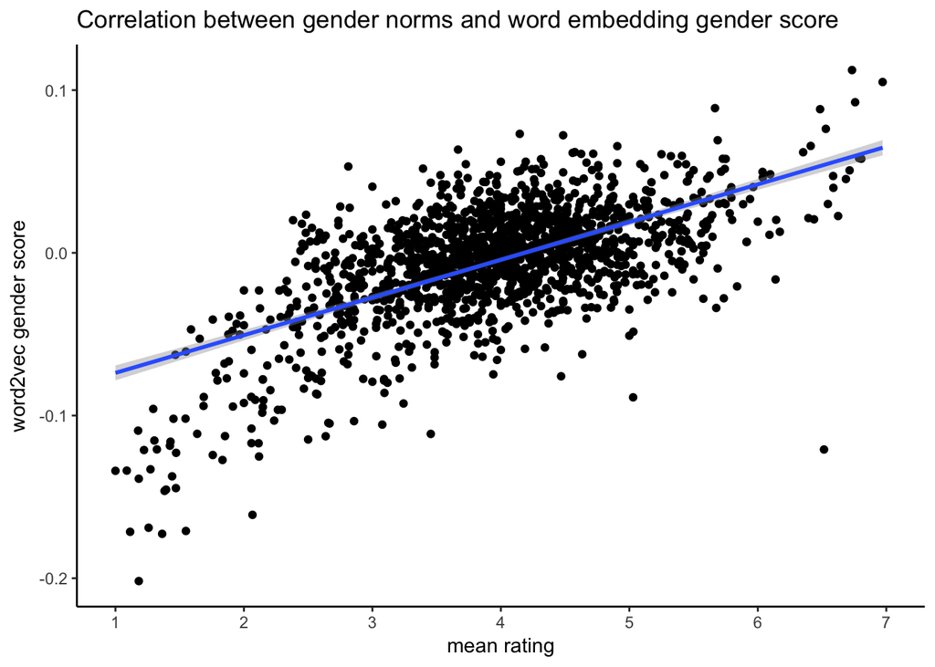

```r
norms <- read_csv("GlasgowNorms.csv") %>%
  select(word, GEND_M, contains("_M"))

all_norms <- left_join(w2v_norms, norms, by = c("target_word"= "word")) %>%
  rename(gender_rating = GEND_M) %>%
  select(target_word, gender_score, gender_rating)


ggplot(all_norms,aes(y = gender_score, x = gender_rating)) +
    geom_point() +
    geom_smooth(method = "lm")  +
    ggtitle("Correlation between gender norms and word embedding gender score")+
    ylab("word2vec gender score") +
    scale_x_continuous(name = "mean rating",
                     limits = c(1, 7),
                     breaks = 1:7) +
  theme_classic()
```

```r
cor_summary <- cor.test(all_norms$gender_score, all_norms$gender_rating)
cor_summary
```

```
##
##  Pearson's product-moment correlation
##
## data:  all_norms$gender_score and all_norms$gender_rating
## t = 30.693, df = 1536, p-value < 2.2e-16
## alternative hypothesis: true correlation is not equal to 0
## 95 percent confidence interval:
##  0.5846044 0.6466275
## sample estimates:
##       cor
## 0.6165717
```

The two measures are highly correlated r = 0.62.

### Mean gender score by book

I calculated this value by averaging across all the words in each book. Books are sorted below by mean gender rating (top = most female)

```r
montag <- read_csv("tidy_montag_corpus.csv") %>%
  rename(target_word = word)

tidy_with_norms <- montag %>%
  left_join(w2v_norms)

norm_means <- tidy_with_norms %>%
  group_by(title) %>%
  multi_boot_standard(col = "gender_score", na.rm = T)

norm_means_wide <- norm_means %>%
  select(title, mean) %>%
  arrange(mean)

kable(norm_means_wide, "html") %>%
  kable_styling() %>%
  scroll_box(width = "900px", height = "400px")
```

| title | mean |
| --- | --- |
| Are You My Mother? | -0.0380492 |
| The Napping House | -0.0347774 |
| Llama Llama Red Pajama | -0.0321110 |
| The Keeping Quilt | -0.0309111 |
| I’m a Big Sister | -0.0305787 |
| Olivia | -0.0296442 |
| Chrysanthemum | -0.0273099 |
| Olivia. . . and the Missing Toy | -0.0215616 |
| Winter Days in the Big Woods | -0.0215347 |
| Bunny Party | -0.0184750 |
| The Gardener | -0.0182586 |
| Goodnight Moon | -0.0172647 |
| Ladybug Girl at the Beach | -0.0170479 |
| Miss Rumphius | -0.0167662 |
| Madeline | -0.0152790 |
| The Runaway Bunny | -0.0141871 |
| Bread and Jam for Frances | -0.0137332 |
| A Bad Case of Stripes | -0.0137075 |
| The Other Side | -0.0136516 |
| Goldilicious | -0.0135043 |
| Charlie and the New Baby | -0.0128609 |
| George and Martha | -0.0125728 |
| Chicka Chicka 1-2-3 | -0.0118135 |
| The Very Hungry Caterpillar | -0.0102064 |
| Love You Forever | -0.0101172 |
| Corduroy | -0.0097333 |
| Angelina Ice Skates | -0.0093384 |
| Knuffle Bunny | -0.0087804 |
| When Dinosaurs came with everything | -0.0084719 |
| Blueberries for Sal | -0.0084425 |

[output cut: 70 more lines]

Distribution of gender ratings across books:

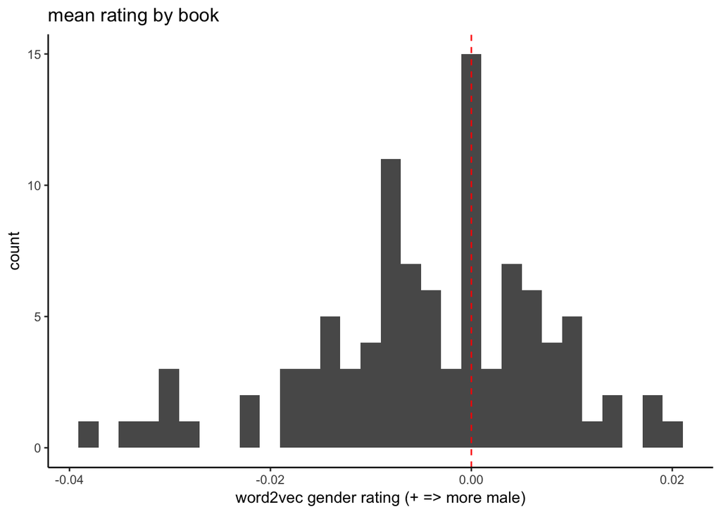

```r
ggplot(norm_means_wide, aes(x = mean)) +
    geom_histogram() +
    ggtitle("mean rating by book") +
    xlab("word2vec gender rating (+ => more male)") +
    geom_vline(aes(xintercept = 0), color = "red", linetype = 2) +
    theme_classic()
```

```r
t.test(norm_means_wide$mean, mu = 0 )
```

```
##
##  One Sample t-test
##
## data:  norm_means_wide$mean
## t = -3.6428, df = 99, p-value = 0.0004314
## alternative hypothesis: true mean is not equal to 0
## 95 percent confidence interval:
##  -0.006596188 -0.001944286
## sample estimates:
##    mean of x
## -0.004270237
```

### Book centroids

Get centroid for each boook, then do tsne, color by male or femalenss

```r
MODEL_PATH <- "wiki.en.vec"

model <- fread(
  MODEL_PATH,
  header = FALSE,
  skip = 1,
  quote = "",
  encoding = "UTF-8",
  data.table = TRUE,
  col.names = c("target_word",
                unlist(lapply(2:301, function(x) paste0("V", x)))))

montag_counts <- read_csv("tidy_montag_corpus.csv") %>%
  rename(target_word = word) %>%
  count(title, target_word)

# get location of essay in the vector space
get_one_essay_location <- function(book_title,
                                   model,
                                   book_data){

  # merge current essay with corresponding word vecs
  merged_vectors <- book_data[title == book_title] %>%
    merge(model, all.x = TRUE, by = "target_word")

  # get pieces to essay vector computation
  word_vectors <- merged_vectors %>%  # get word vectors only
    select(V2:V301) %>%
    as.matrix()
  counts <- merged_vectors$n # get counts

  # weighted by number of times word appears in essay
  count_weighted_vecs <- word_vectors * counts # weight by n word appears
  essay_vector_count_weighted <- t(colSums(count_weighted_vecs,
                                           na.rm = TRUE)) # sum across words

  # return essay vector
  count_weighting_vec <- data.frame(title = book_title,
                                    essay_vector_count_weighted)

}

essay_locations <-
  map_df(unique(montag_counts$title),
         get_one_essay_location, model,
         as.data.table(montag_counts))

# get tsne coordinates
tsne_out = Rtsne::Rtsne(as.matrix(essay_locations[,-1]))
tsne_dims <- tsne_out$Y %>%
  as.data.frame() %>%
  rename(tsne_X = V1,
         tsne_Y = V2)

write_csv(tsne_dims, "book_tsne.csv")
```

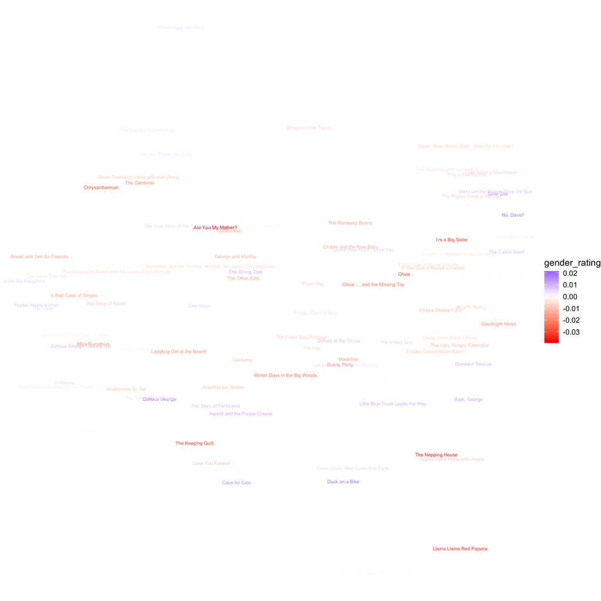

```r
tsne_dims <- read_csv("book_tsne.csv") %>%
  bind_cols(gender_rating = norm_means$mean)  %>%
  bind_cols(title = norm_means$title)  %>%
  mutate(gender_rating_cat = ifelse(gender_rating > 0,
                                    "male", "female"))


  ggplot(tsne_dims,
         aes(x = tsne_X, y = tsne_Y, color = gender_rating)) +
  geom_text(aes(label = title, color = gender_rating), size = 2) +
  #geom_point() +
  scale_color_gradient2(low = "red", high = "blue") +
    theme_void()
```

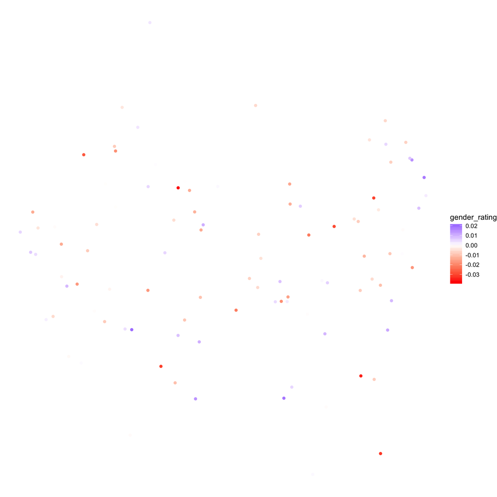

```r
ggplot(tsne_dims,
         aes(x = tsne_X, y = tsne_Y, color = gender_rating)) +
  scale_color_gradient2(low = "red", high = "blue") +
  geom_point() +
  theme_void()
```

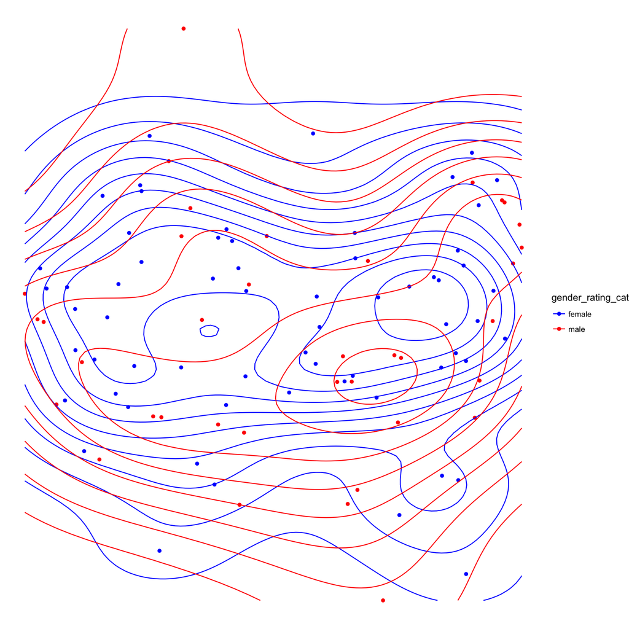

```r
ggplot(tsne_dims,
         aes(x = tsne_X, y = tsne_Y, color = gender_rating_cat)) +
  scale_color_manual(values = c("blue", "red")) +
  geom_point() +
    geom_density_2d() +

  theme_void()
```